# Hypothesis testing on A/B tests

## Research purpose

Identify hypotheses that will help increase the revenue of the online store.

## Research description

Prepare a list of hypotheses to increase revenue of a large online store. Prioritize hypotheses, run an A/B test and analyze the results.

## Data description

`hypothesis.csv` structure  
Hypothesis — a brief description of the hypothesis;  
Reach — user coverage on a 10-point scale;  
Impact — impact on users on a 10-point scale;  
Confidence — confidence in the hypothesis on a 10-point scale;  
Efforts — the cost of resources to test the hypothesis on a 10-point scale. The greater the value of Efforts, the more expensive hypothesis testing is.

`Orders.csv` structure  
TransactionID — order ID;  
visitorID — ID of the user who made the order;  
date — the date when the order was made; revenue — order revenue;  
group — the A/B test group that the order fell into.

`Visitors.csv` structure  
date — date;  
group — A/B test group;  
visitors — the number of users on the specified date in the specified A/B test group

```python
import pandas as pd
import matplotlib.pyplot as plt
import numpy as np
import scipy.stats as stats
```

```python
try:
    hypothesis = pd.read_csv('hypothesis.csv')
    orders = pd.read_csv('orders.csv', parse_dates=['date'])
    visitors = pd.read_csv('visitors.csv', parse_dates=['date'])
except:
    hypothesis = pd.read_csv('datasets/hypothesis.csv')
    orders = pd.read_csv('datasets/orders.csv')
    visitors = pd.read_csv('datasets/visitors.csv')
```

## Data preprocessing

```python
def first_look (df):
    print('------------- First 5 lines ------------')
    display(df.sample(5))
    print('------------- Data types ------------')
    display(df.info())
    print('------------- Gaps ------------')
    for element in df.columns:
        if df[element].isna().any().mean() > 0:
            print(element, '-', df[element].isna().sum())
        else:
            print(element, '- None')
    print('------------- Duplicates ------------')
    if df.duplicated().sum() > 0:
        print(df.duplicated().sum())
    else:
        print('No Duplicates')
```

### Dataset hypothesis

```python
first_look(hypothesis)
```

```
------------- First 5 lines ------------
```

|  | Hypothesis | Reach | Impact | Confidence | Efforts |
| --- | --- | --- | --- | --- | --- |
| 1 | Запустить собственную службу доставки, что сок... | 2 | 5 | 4 | 10 |
| 4 | Изменить цвет фона главной страницы, чтобы уве... | 3 | 1 | 1 | 1 |
| 8 | Запустить акцию, дающую скидку на товар в день... | 1 | 9 | 9 | 5 |
| 2 | Добавить блоки рекомендаций товаров на сайт ин... | 8 | 3 | 7 | 3 |
| 3 | Изменить структура категорий, что увеличит кон... | 8 | 3 | 3 | 8 |

```
------------- Data types ------------
<class 'pandas.core.frame.DataFrame'>
RangeIndex: 9 entries, 0 to 8
Data columns (total 5 columns):
 #   Column      Non-Null Count  Dtype
---  ------      --------------  -----
 0   Hypothesis  9 non-null      object
 1   Reach       9 non-null      int64
 2   Impact      9 non-null      int64
 3   Confidence  9 non-null      int64
 4   Efforts     9 non-null      int64
dtypes: int64(4), object(1)
memory usage: 488.0+ bytes
```

```
None
```

```
------------- Gaps ------------
Hypothesis - None
Reach - None
Impact - None
Confidence - None
Efforts - None
------------- Duplicates ------------
No Duplicates
```

The data is clean, without omissions and duplicates.  
Let's bring the columns to the lower case.

```python
hypothesis.columns = hypothesis.columns.str.lower()
display(hypothesis.sample())
```

|  | hypothesis | reach | impact | confidence | efforts |
| --- | --- | --- | --- | --- | --- |
| 8 | Запустить акцию, дающую скидку на товар в день... | 1 | 9 | 9 | 5 |

### Prioritization of hypotheses by the ICE framework. Sort them in descending order of priority

ICE (confidence, effort, reach):
$$ICE = \frac{Impact * Confidence}{Efforts}$$

```python
hypothesis['ice'] = round((hypothesis['impact'] * hypothesis['confidence'])/hypothesis['efforts'], 2)
display(hypothesis.sort_values(by='ice', ascending=False).head(5))
```

|  | hypothesis | reach | impact | confidence | efforts | ice |
| --- | --- | --- | --- | --- | --- | --- |
| 8 | Запустить акцию, дающую скидку на товар в день... | 1 | 9 | 9 | 5 | 16.20 |
| 0 | Добавить два новых канала привлечения трафика,... | 3 | 10 | 8 | 6 | 13.33 |
| 7 | Добавить форму подписки на все основные страни... | 10 | 7 | 8 | 5 | 11.20 |
| 6 | Показать на главной странице баннеры с актуаль... | 5 | 3 | 8 | 3 | 8.00 |
| 2 | Добавить блоки рекомендаций товаров на сайт ин... | 8 | 3 | 7 | 3 | 7.00 |

### Prioritization of hypotheses by the RICE framework. Sort them in descending order of priority

RICE (influence, confidence, effort, reach):
$$RICE = \frac{Rearch * Impact * Confidence}{Efforts}$$

```python
hypothesis['rice'] = round((hypothesis['reach'] * hypothesis['impact'] * hypothesis['confidence'])/hypothesis['efforts'], 2)
display(hypothesis.sort_values(by='rice', ascending=False).head(5))
```

|  | hypothesis | reach | impact | confidence | efforts | ice | rice |
| --- | --- | --- | --- | --- | --- | --- | --- |
| 7 | Добавить форму подписки на все основные страни... | 10 | 7 | 8 | 5 | 11.20 | 112.0 |
| 2 | Добавить блоки рекомендаций товаров на сайт ин... | 8 | 3 | 7 | 3 | 7.00 | 56.0 |
| 0 | Добавить два новых канала привлечения трафика,... | 3 | 10 | 8 | 6 | 13.33 | 40.0 |
| 6 | Показать на главной странице баннеры с актуаль... | 5 | 3 | 8 | 3 | 8.00 | 40.0 |
| 8 | Запустить акцию, дающую скидку на товар в день... | 1 | 9 | 9 | 5 | 16.20 | 16.2 |

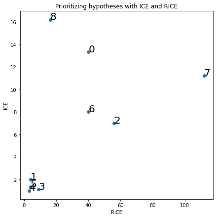

```python
y = hypothesis['ice']
z = hypothesis['rice']
n = hypothesis.index

fig, ax = plt.subplots()
ax.scatter(z, y)

for i, txt in enumerate(n):
    ax.annotate(txt, (z[i], y[i]), size=20)

plt.title("Prioritizing hypotheses with ICE and RICE")
plt.xlabel("RICE")
plt.ylabel("ICE")
fig.set_figheight(7)
fig.set_figwidth(7)

plt.show();
```

The prioritization of hypotheses when using RICE instead of ICE has changed due to the inclusion of an additional evaluation factor Reach - audience reach.  
Thus, the priority of the hypothesis can be very high, but in a narrow group of users. That on the scale of all recipients of the hypothesis will be insignificant.  
The introduction of the Reach criterion, meaning influence, coverage, increases the reliability of the assessment of the priority of the hypothesis.

### Dataset orders

```python
first_look(orders)
```

```
------------- First 5 lines ------------
```

|  | transactionId | visitorId | date | revenue | group |
| --- | --- | --- | --- | --- | --- |
| 1099 | 316924019 | 148427295 | 2019-08-12 | 65710 | A |
| 1172 | 3898641900 | 3803269165 | 2019-08-14 | 790 | B |
| 312 | 3524589317 | 2986402114 | 2019-08-24 | 990 | B |
| 316 | 4226817726 | 1349865791 | 2019-08-19 | 2490 | A |
| 873 | 2519737434 | 4256040402 | 2019-08-08 | 58220 | B |

```
------------- Data types ------------
<class 'pandas.core.frame.DataFrame'>
RangeIndex: 1197 entries, 0 to 1196
Data columns (total 5 columns):
 #   Column         Non-Null Count  Dtype
---  ------         --------------  -----
 0   transactionId  1197 non-null   int64
 1   visitorId      1197 non-null   int64
 2   date           1197 non-null   object
 3   revenue        1197 non-null   int64
 4   group          1197 non-null   object
dtypes: int64(3), object(2)
memory usage: 46.9+ KB
```

```
None
```

```
------------- Gaps ------------
transactionId - None
visitorId - None
date - None
revenue - None
group - None
------------- Duplicates ------------
No Duplicates
```

The data is clean, without omissions and duplicates.  
The dt column will be converted to the datetime format.  
Let's bring the columns to the lower case.

```python
display('Number of users in each group')
orders.groupby(['group'])['visitorId'].nunique()
```

```
'Number of users in each group'
```

```
group
A    503
B    586
Name: visitorId, dtype: int64
```

```python
display('Number of visits in each group')
orders.groupby(['group'])['visitorId'].count()
```

```
'Number of visits in each group'
```

```
group
A    557
B    640
Name: visitorId, dtype: int64
```

```python
display('Test start date in in groups:', orders.groupby(['group'])['date'].min())
display('Test end date in in groups:', orders.groupby(['group'])['date'].max())
```

```
'Test start date in in groups:'
```

```
group
A    2019-08-01
B    2019-08-01
Name: date, dtype: object
```

```
'Test end date in in groups:'
```

```
group
A    2019-08-31
B    2019-08-31
Name: date, dtype: object
```

- The start and end dates in the groups are the same
- The number of groups corresponds to the stated
- The number of users will not exceed the number of visits

### Dataset visitors

```python
first_look(visitors)
```

```
------------- First 5 lines ------------
```

|  | date | group | visitors |
| --- | --- | --- | --- |
| 25 | 2019-08-26 | A | 722 |
| 38 | 2019-08-08 | B | 654 |
| 5 | 2019-08-06 | A | 667 |
| 26 | 2019-08-27 | A | 711 |
| 56 | 2019-08-26 | B | 676 |

```
------------- Data types ------------
<class 'pandas.core.frame.DataFrame'>
RangeIndex: 62 entries, 0 to 61
Data columns (total 3 columns):
 #   Column    Non-Null Count  Dtype
---  ------    --------------  -----
 0   date      62 non-null     object
 1   group     62 non-null     object
 2   visitors  62 non-null     int64
dtypes: int64(1), object(2)
memory usage: 1.6+ KB
```

```
None
```

```
------------- Gaps ------------
date - None
group - None
visitors - None
------------- Duplicates ------------
No Duplicates
```

The data is clean, without omissions and duplicates.  
The date column will be converted to the datetime format.

```python
display('Number of visits by groups in the visitors dataset')
visitors.groupby(['group'])['visitors'].sum()
```

```
'Number of visits by groups in the visitors dataset'
```

```
group
A    18736
B    18916
Name: visitors, dtype: int64
```

```python
# Let's check the uniqueness of users in each group
usersInGroups = orders.groupby(['visitorId'], as_index=False).agg({'group':['first','nunique']})
usersInGroups.columns = ['visitorId', 'group', 'groupcount']
usersInBothGroups = usersInGroups[usersInGroups['groupcount'] != 1][['visitorId', 'group']]
display(usersInBothGroups.head(5))
display(usersInBothGroups.shape[0])
```

|  | visitorId | group |
| --- | --- | --- |
| 2 | 8300375 | B |
| 44 | 199603092 | A |
| 51 | 232979603 | B |
| 55 | 237748145 | B |
| 66 | 276558944 | B |

```
58
```

58 defectors were found. With the volume of both groups in 1000, it is impossible to delete 58 users - 6%.  
All users who have made more than 1 order are in the defector group.  
Assign each such user a group in which they made the first order.

```python
orders.columns = ['transactionId','visitorId','date','revenue','groupOld']
orders = orders.merge(usersInBothGroups, on='visitorId', how='left')
display(orders.head(5))
```

|  | transactionId | visitorId | date | revenue | groupOld | group |
| --- | --- | --- | --- | --- | --- | --- |
| 0 | 3667963787 | 3312258926 | 2019-08-15 | 1650 | B | NaN |
| 1 | 2804400009 | 3642806036 | 2019-08-15 | 730 | B | NaN |
| 2 | 2961555356 | 4069496402 | 2019-08-15 | 400 | A | A |
| 3 | 3797467345 | 1196621759 | 2019-08-15 | 9759 | B | NaN |
| 4 | 2282983706 | 2322279887 | 2019-08-15 | 2308 | B | NaN |

```python
orders['group'] = orders.apply(lambda x: x['groupOld'] if pd.isna(x['group']) == True else x['group'] , axis=1)
display('Uniqueness of users in each group')
usersInGroups2 = orders.groupby(['visitorId'], as_index=False).agg({'group':'nunique'})
usersInGroups2.columns = ['visitorId', 'groupcount']
usersInBothGroups2 = usersInGroups2[usersInGroups2['groupcount'] != 1]['visitorId']
display(usersInBothGroups2.head(5))
display(usersInBothGroups2.shape[0])
```

```
'Uniqueness of users in each group'
```

```
Series([], Name: visitorId, dtype: int64)
```

```
0
```

## Data analysis

### Cumulative revenue graph by group

```python
# creating an array of unique pairs of date values and test groups
datesGroups = orders[['date','group']].drop_duplicates()

ordersAggregated = datesGroups.apply(lambda x: orders[np.logical_and(orders['date'] <= x['date'],
                                                                     orders['group'] == x['group'])]\
.agg({'date' : 'max',
      'group' : 'max',
      'transactionId' : 'nunique',
      'visitorId' : 'nunique',
      'revenue' : 'sum'}), axis=1).sort_values(by=['date','group'])

visitorsAggregated = datesGroups.apply(lambda x: visitors[np.logical_and(visitors['date'] <= x['date'],
                                                                         visitors['group'] == x['group'])]\
                                       .agg({'date' : 'max',
                                             'group' : 'max',
                                             'visitors' : 'sum'}), axis=1).sort_values(by=['date','group'])

# we combine cumulative data in one table and assign understandable names to its columns
cumulativeData = ordersAggregated.merge(visitorsAggregated, left_on=['date', 'group'], right_on=['date', 'group'])
cumulativeData.columns = ['date', 'group', 'orders', 'buyers', 'revenue', 'visitors']

display(cumulativeData.head(5))
# Checking the integrity of the new dataframe
display(cumulativeData['date'].min())
display(cumulativeData['date'].max())
```

|  | date | group | orders | buyers | revenue | visitors |
| --- | --- | --- | --- | --- | --- | --- |
| 0 | 2019-08-01 | A | 23 | 19 | 142779 | 719 |
| 1 | 2019-08-01 | B | 22 | 21 | 107017 | 713 |
| 2 | 2019-08-02 | A | 43 | 37 | 237869 | 1338 |
| 3 | 2019-08-02 | B | 46 | 43 | 271280 | 1294 |
| 4 | 2019-08-03 | A | 67 | 61 | 350342 | 1845 |

```
'2019-08-01'
```

```
'2019-08-31'
```

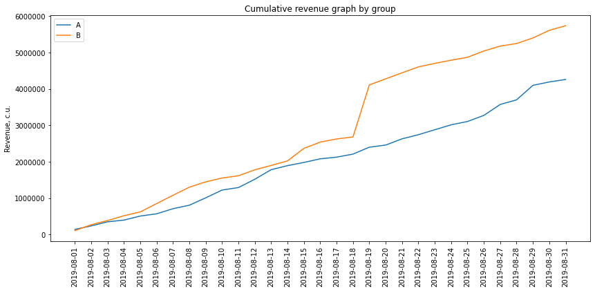

```python
# dataframe with cumulative number of orders and cumulative revenue by day in Group A
cumulativeRevenueA = cumulativeData[cumulativeData['group']=='A'][['date','revenue', 'orders']]

# dataframe with cumulative number of orders and cumulative revenue by day in group B
cumulativeRevenueB = cumulativeData[cumulativeData['group']=='B'][['date','revenue', 'orders']]

# Plotting the revenue of Group A
plt.figure(figsize=(14, 6))

plt.plot(cumulativeRevenueA['date'], cumulativeRevenueA['revenue'], label='A');

# Plotting the revenue of Group B
plt.plot(cumulativeRevenueB['date'], cumulativeRevenueB['revenue'], label='B');
plt.ticklabel_format(style='plain', useOffset=False, axis='y')
plt.legend()
plt.title("Cumulative revenue graph by group")
plt.ylabel("Revenue, c.u.")
plt.xticks(rotation=90);
```

The schedules of both groups are growing, which means that revenue increases over time.  
A sharp jump in Group B's revenue around 08/18/2019 indicates a sharp jump in the number of orders or the cost of orders.

### Graph of the cumulative average check by group

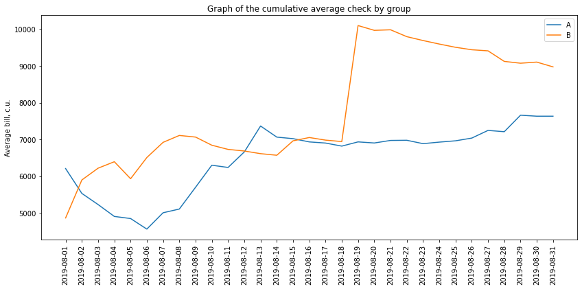

```python
plt.figure(figsize=(14, 6))
plt.plot(cumulativeRevenueA['date'], cumulativeRevenueA['revenue']/cumulativeRevenueA['orders'], label='A')
plt.plot(cumulativeRevenueB['date'], cumulativeRevenueB['revenue']/cumulativeRevenueB['orders'], label='B')
plt.legend()
plt.title("Graph of the cumulative average check by group")
plt.ylabel("Average bill, c.u.")
plt.xticks(rotation=90);
```

On the chart of the average check for group B, there is also a jump in the area of 18.08.2019.  
This suggests that the reason for this jump is in the cost of orders.  
Further, the chart shows a downward trend and tries to stabilize after the jump. So we should continue the experiment until the stabilization of group B.  
The average receipt of group A also had several peaks and falls, but judging by the revenue schedule, they were compensated by the number of orders and by the end of the experiment, the schedule of group A stabilized.

### Graph of the relative change in the cumulative average check of group B to group A

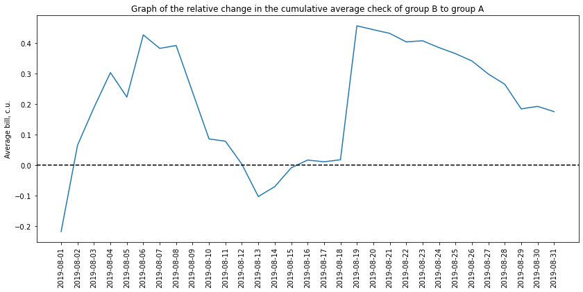

```python
mergedCumulativeRevenue = cumulativeRevenueA.merge(cumulativeRevenueB, left_on='date',
                                                   right_on='date', how='left', suffixes=['A', 'B'])

# Building the ratio of average checks
plt.figure(figsize=(14, 6))
plt.plot(mergedCumulativeRevenue['date'],
         (mergedCumulativeRevenue['revenueB']/mergedCumulativeRevenue['ordersB'])
         /(mergedCumulativeRevenue['revenueA']/mergedCumulativeRevenue['ordersA'])-1)

# Adding the X axis
plt.axhline(y=0, color='black', linestyle='--')
plt.ylabel("Average bill, c.u.")
plt.title("Graph of the relative change in the cumulative average check of group B to group A")
plt.xticks(rotation=90);
```

The chart largely repeats the peaks and falls of the average check chart.  
Obviously there are outliers in the data.

### Cumulative conversion graph by group

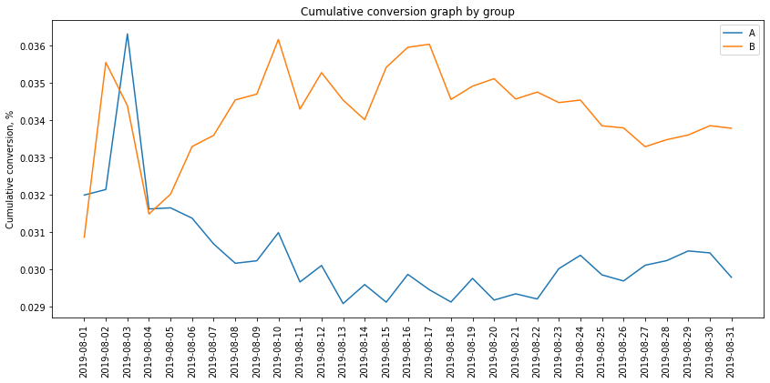

```python
# we consider cumulative conversion
cumulativeData['conversion'] = cumulativeData['orders']/cumulativeData['visitors']

# separating the data by group A
cumulativeDataA = cumulativeData[cumulativeData['group']=='A']

# separating the data by group B
cumulativeDataB = cumulativeData[cumulativeData['group']=='B']

# building graphs
plt.figure(figsize=(14, 6))
plt.plot(cumulativeDataA['date'], cumulativeDataA['conversion'], label='A')
plt.plot(cumulativeDataB['date'], cumulativeDataB['conversion'], label='B')
plt.legend()
plt.ylabel("Cumulative conversion, %")
plt.title("Cumulative conversion graph by group")
plt.xticks(rotation=90);
```

After August 5, the conversion of group B exceeded the conversion of group A. Further, the conversion values stabilized and the advantage of group B remained

### Graph of the relative change in the cumulative conversion of group B to group A

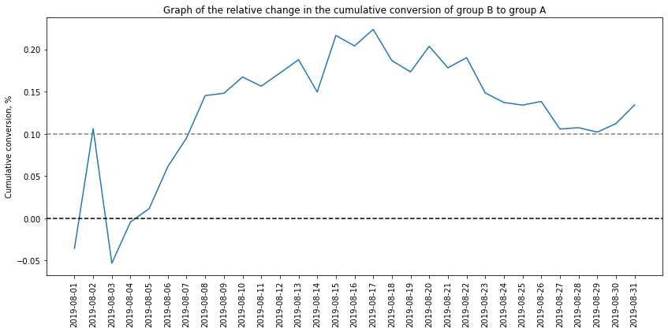

```python
mergedCumulativeConversions = cumulativeDataA[['date','conversion']].merge(cumulativeDataB[['date','conversion']],
                                                                           left_on='date',
                                                                           right_on='date',
                                                                           how='left', suffixes=['A', 'B'])

plt.figure(figsize=(14, 6))
plt.plot(mergedCumulativeConversions['date'],
         mergedCumulativeConversions['conversionB']/mergedCumulativeConversions['conversionA']-1)

plt.ylabel("Cumulative conversion, %")
plt.title("Graph of the relative change in the cumulative conversion of group B to group A")
plt.axhline(y=0, color='black', linestyle='--')
plt.axhline(y=0.1, color='grey', linestyle='--')
plt.xticks(rotation=90);
```

### Dot graph of the number of orders by users

```python
## Let's count the number of orders by users
ordersByUsers = (
    orders.groupby('visitorId', as_index=False)
    .agg({'transactionId': 'nunique'})
)

ordersByUsers.columns = ['visitorId', 'orders']

display(ordersByUsers.sort_values(by='orders', ascending=False).head(5))
```

|  | visitorId | orders |
| --- | --- | --- |
| 1023 | 4256040402 | 11 |
| 591 | 2458001652 | 11 |
| 569 | 2378935119 | 9 |
| 487 | 2038680547 | 8 |
| 44 | 199603092 | 5 |

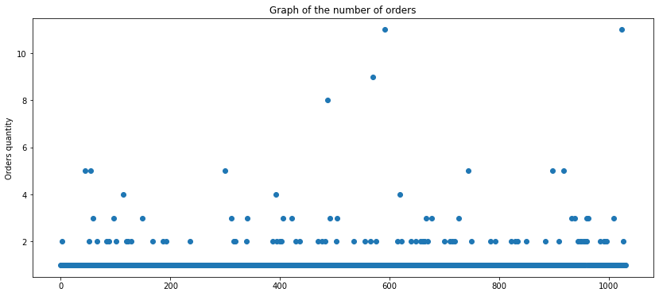

```python
x_values = pd.Series(range(0,len(ordersByUsers)))
plt.figure(figsize=(14, 6))
plt.title("Graph of the number of orders")
plt.ylabel("Orders quantity")
plt.scatter(x_values, ordersByUsers['orders']);
```

### Determining the boundary of abnormal users by the number of orders

```python
## Calculate the sample percentiles of the number of orders per user
print(np.percentile(ordersByUsers['orders'], [90, 95, 99]))
```

```
[1. 2. 4.]
```

10% of users ordered more than once.  
No more than 5% of users have placed more than 2 orders.

Let's take 2 orders per user for the upper limit of the number of orders.

### Dot chart of order values

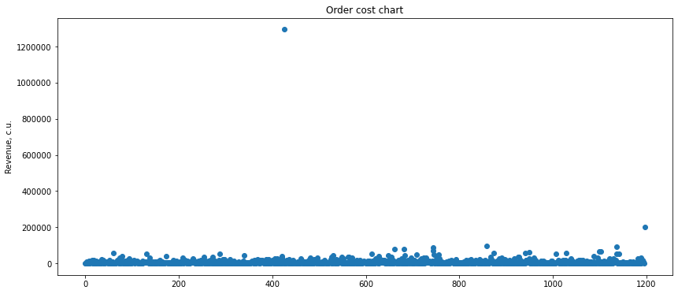

```python
x_values = pd.Series(range(0,len(orders['revenue'])))
plt.figure(figsize=(14, 6))
plt.ylabel("Revenue, c.u.")
plt.title("Order cost chart")
plt.ticklabel_format(style='plain')
plt.scatter(x_values, orders['revenue']);
```

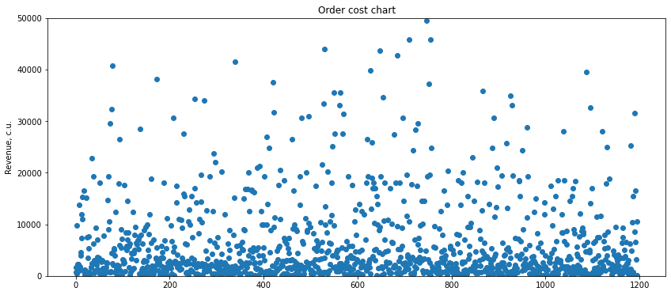

```python
x_values = pd.Series(range(0,len(orders['revenue'])))
plt.figure(figsize=(14, 6))
plt.ylabel("Revenue, c.u.")
plt.title("Order cost chart")
plt.ticklabel_format(style='plain')
plt.ylabel("Revenue, c.u.")
plt.ylim([0,50000])
plt.scatter(x_values, orders['revenue']);
```

There are only a few expensive orders, the bulk of orders within 30,000

### Determining the boundary of abnormal users by the cost of orders

```python
print(np.percentile(orders['revenue'], [90, 95, 99]))
```

```
[18168.  28000.  58233.2]
```

No more than 5% of orders are more expensive than 28,000 rubles and no more than 1% are more expensive than 58,233 rubles.  
We will accept 28,000 rubles for the upper limit of the cost of orders.

### Hypothesis check of conversion difference between groups on "raw" data

Calculation of the statistical significance of differences in conversion between groups based on "raw" data — without removing abnormal users.  
**Null hypothesis**  
H0: There are no differences in conversion between the groups.  
**Alternative hypothesis**  
H1: there are differences in conversion between groups

```python
visitorsADaily = visitors[visitors['group'] == 'A'][['date', 'visitors']]
visitorsADaily.columns = ['date', 'visitorsPerDateA']

visitorsBDaily = visitors[visitors['group'] == 'B'][['date', 'visitors']]
visitorsBDaily.columns = ['date', 'visitorsPerDateB']

visitorsACummulative = visitorsADaily.apply(
    lambda x: visitorsADaily[visitorsADaily['date'] <= x['date']].agg(
        {'date': 'max', 'visitorsPerDateA': 'sum'}
    ),
    axis=1,
)
visitorsACummulative.columns = ['date', 'visitorsCummulativeA']

visitorsBCummulative = visitorsBDaily.apply(
    lambda x: visitorsBDaily[visitorsBDaily['date'] <= x['date']].agg(
        {'date': 'max', 'visitorsPerDateB': 'sum'}
    ),
    axis=1,
)
visitorsBCummulative.columns = ['date', 'visitorsCummulativeB']

ordersADaily = (
    orders[orders['group'] == 'A'][['date', 'transactionId', 'visitorId', 'revenue']]
    .groupby('date', as_index=False)
    .agg({'transactionId': pd.Series.nunique, 'revenue': 'sum'})
)
ordersADaily.columns = ['date', 'ordersPerDateA', 'revenuePerDateA']

ordersBDaily = (
    orders[orders['group'] == 'B'][['date', 'transactionId', 'visitorId', 'revenue']]
    .groupby('date', as_index=False)
    .agg({'transactionId': pd.Series.nunique, 'revenue': 'sum'})
)
ordersBDaily.columns = ['date', 'ordersPerDateB', 'revenuePerDateB']

ordersACummulative = ordersADaily.apply(
    lambda x: ordersADaily[ordersADaily['date'] <= x['date']].agg(
        {'date': 'max', 'ordersPerDateA': 'sum', 'revenuePerDateA': 'sum'}
    ),
    axis=1,
).sort_values(by=['date'])
ordersACummulative.columns = [
    'date',
    'ordersCummulativeA',
    'revenueCummulativeA',
]

ordersBCummulative = ordersBDaily.apply(
    lambda x: ordersBDaily[ordersBDaily['date'] <= x['date']].agg(
        {'date': 'max', 'ordersPerDateB': 'sum', 'revenuePerDateB': 'sum'}
    ),
    axis=1,
).sort_values(by=['date'])
ordersBCummulative.columns = [
    'date',
    'ordersCummulativeB',
    'revenueCummulativeB',
]

data = (
    ordersADaily.merge(
        ordersBDaily, left_on='date', right_on='date', how='left'
    )
    .merge(ordersACummulative, left_on='date', right_on='date', how='left')
    .merge(ordersBCummulative, left_on='date', right_on='date', how='left')
    .merge(visitorsADaily, left_on='date', right_on='date', how='left')
    .merge(visitorsBDaily, left_on='date', right_on='date', how='left')
    .merge(visitorsACummulative, left_on='date', right_on='date', how='left')
    .merge(visitorsBCummulative, left_on='date', right_on='date', how='left')
)
data['conversionA'] = data['ordersPerDateA']/data['visitorsPerDateA']
data['conversionB'] = data['ordersPerDateB']/data['visitorsPerDateB']
data['conversionCummulativeA'] = data['ordersCummulativeA']/data['visitorsCummulativeA']
data['conversionCummulativeB'] = data['ordersCummulativeB']/data['visitorsCummulativeB']
display(data.head(5))
```

|  | date | ordersPerDateA | revenuePerDateA | ordersPerDateB | revenuePerDateB | ordersCummulativeA | revenueCummulativeA | ordersCummulativeB | revenueCummulativeB | visitorsPerDateA | visitorsPerDateB | visitorsCummulativeA | visitorsCummulativeB | conversionA | conversionB | conversionCummulativeA | conversionCummulativeB |
| --- | --- | --- | --- | --- | --- | --- | --- | --- | --- | --- | --- | --- | --- | --- | --- | --- | --- |
| 0 | 2019-08-01 | 23 | 142779 | 22 | 107017 | 23 | 142779 | 22 | 107017 | 719 | 713 | 719 | 713 | 0.031989 | 0.030856 | 0.031989 | 0.030856 |
| 1 | 2019-08-02 | 20 | 95090 | 24 | 164263 | 43 | 237869 | 46 | 271280 | 619 | 581 | 1338 | 1294 | 0.032310 | 0.041308 | 0.032138 | 0.035549 |
| 2 | 2019-08-03 | 24 | 112473 | 16 | 114248 | 67 | 350342 | 62 | 385528 | 507 | 509 | 1845 | 1803 | 0.047337 | 0.031434 | 0.036314 | 0.034387 |
| 3 | 2019-08-04 | 14 | 47016 | 19 | 132380 | 81 | 397358 | 81 | 517908 | 717 | 770 | 2562 | 2573 | 0.019526 | 0.024675 | 0.031616 | 0.031481 |
| 4 | 2019-08-05 | 24 | 111753 | 24 | 104893 | 105 | 509111 | 105 | 622801 | 756 | 707 | 3318 | 3280 | 0.031746 | 0.033946 | 0.031646 | 0.032012 |

```python
print('P-value = ', format(stats.mannwhitneyu(data['conversionA'], data['conversionB'])[1]))
print('Relative differences between groups = {0:.3f}'.format(data['conversionB'].mean()/data['conversionA'].mean()-1))
```

```
P-value =  0.10244491051997041
Relative differences between groups = 0.141
```

### Hypothesis check of average number of orders difference between groups on "raw" data

Calculation of the statistical significance of differences in the average number of orders between groups based on "raw" data — without removing abnormal users.  
**Null hypothesis**  
H0: There are no differences in the average number of orders between the groups.  
**Alternative hypothesis**  
H1: there are differences in the average number of orders between groups

```python
ordersByUsersA = (
    orders[orders['group'] == 'A']
    .groupby('visitorId', as_index=False)
    .agg({'transactionId': pd.Series.nunique})
)
ordersByUsersA.columns = ['visitorId', 'orders']

ordersByUsersB = (
    orders[orders['group'] == 'B']
    .groupby('visitorId', as_index=False)
    .agg({'transactionId': pd.Series.nunique})
)
ordersByUsersB.columns = ['visitorId', 'orders']

sampleA = pd.concat(
    [ordersByUsersA['orders'],
        pd.Series(0,index=np.arange(
                data['visitorsPerDateA'].sum() - len(ordersByUsersA['orders'])),name='orders',),],axis=0,)

sampleB = pd.concat(
    [ordersByUsersB['orders'],
        pd.Series(0,index=np.arange(
                data['visitorsPerDateB'].sum() - len(ordersByUsersB['orders'])),name='orders',),],axis=0,)

print('P-value = ', format(stats.mannwhitneyu(sampleA, sampleB)[1]))
print('Relative differences between groups = {0:.3f}'.format(sampleB.mean() / sampleA.mean() - 1))
```

```
P-value =  0.016658509222998077
Relative differences between groups = 0.134
```

#### Interim summary

According to the "raw" data, there are differences in the average number of orders of groups A and B.  
The first number is p—value = 0.017 less than 0.05. Therefore, we do not reject the alternative hypothesis that there are statistically significant differences in the average number of orders between groups.

## The relative gain of Group B equal to 13% is statistically significant.

### Hypothesis check of average order receipt difference between groups on "raw" data

Calculation of the statistical significance of differences in average order receipt between groups based on "raw" data — without removing abnormal users.  
**Null hypothesis**  
H0: There are no differences in average order receipt between the groups.  
**Alternative hypothesis**  
H1: there are differences in average order receipt between groups

```python
print('P-value = ',format(stats.mannwhitneyu(orders[orders['group']=='A']['revenue'],
                                                    orders[orders['group']=='B']['revenue'])[1]))
print('Relative differences between groups = {0:.3f}'.format(orders[orders['group']=='B']['revenue'].mean()/orders[orders['group']=='A']['revenue'].mean()-1))
```

```
P-value =  0.6459350227105034
Relative differences between groups = 0.176
```

#### Interim summary

The P-value is significantly greater than 0.05. Therefore, there is no reason to reject the null hypothesis and assume that there are differences in the average check.  
The average check of group B is 18% higher than the average check of group A, but this difference is not statistically significant.

The 95th and 99th percentiles of the average checks found in p.5.9 are equal to 28,000 and 58,233 rubles.  
And the 95th and 99th percentiles of the number of orders per user are 2 and 4 orders per user.

```python
ordersByUsersA = (
    orders[orders['group'] == 'A']
    .groupby('visitorId', as_index=False)
    .agg({'transactionId': pd.Series.nunique})
)
ordersByUsersA.columns = ['visitorId', 'orders']

ordersByUsersB = (
    orders[orders['group'] == 'B']
    .groupby('visitorId', as_index=False)
    .agg({'transactionId': pd.Series.nunique})
)
ordersByUsersB.columns = ['visitorId', 'orders']

usersWithManyOrders = pd.concat(
    [
        ordersByUsersA[ordersByUsersA['orders'] > np.percentile(ordersByUsers['orders'], [95])[0]]['visitorId'],
        ordersByUsersB[ordersByUsersB['orders'] > np.percentile(ordersByUsers['orders'], [95])[0]]['visitorId'],
    ],
    axis=0,
)
usersWithExpensiveOrders = orders[orders['revenue'] > np.percentile(orders['revenue'], [95])[0]]['visitorId']
abnormalUsers = (
    pd.concat([usersWithManyOrders, usersWithExpensiveOrders], axis=0)
    .drop_duplicates()
    .sort_values()
)
print(abnormalUsers.head(5))
display(abnormalUsers.shape[0])
```

```
1099    148427295
17      199603092
928     204675465
34      237748145
36      249864742
Name: visitorId, dtype: int64
```

```
83
```

```python
visitorsADaily = visitors[visitors['group'] == 'A'][['date', 'visitors']]
visitorsADaily.columns = ['date', 'visitorsPerDateA']

visitorsBDaily = visitors[visitors['group'] == 'B'][['date', 'visitors']]
visitorsBDaily.columns = ['date', 'visitorsPerDateB']

visitorsACummulative = visitorsADaily.apply(
    lambda x: visitorsADaily[visitorsADaily['date'] <= x['date']].agg(
        {'date': 'max', 'visitorsPerDateA': 'sum'}
    ),
    axis=1,
)
visitorsACummulative.columns = ['date', 'visitorsCummulativeA']

visitorsBCummulative = visitorsBDaily.apply(
    lambda x: visitorsBDaily[visitorsBDaily['date'] <= x['date']].agg(
        {'date': 'max', 'visitorsPerDateB': 'sum'}
    ),
    axis=1,
)
visitorsBCummulative.columns = ['date', 'visitorsCummulativeB']

ordersADaily = (
    orders[orders['group'] == 'A'][['date', 'transactionId', 'visitorId', 'revenue']]
    .groupby('date', as_index=False)
    .agg({'transactionId': pd.Series.nunique, 'revenue': 'sum'})
)
ordersADaily.columns = ['date', 'ordersPerDateA', 'revenuePerDateA']

ordersBDaily = (
    orders[orders['group'] == 'B'][['date', 'transactionId', 'visitorId', 'revenue']]
    .groupby('date', as_index=False)
    .agg({'transactionId': pd.Series.nunique, 'revenue': 'sum'})
)
ordersBDaily.columns = ['date', 'ordersPerDateB', 'revenuePerDateB']

ordersACummulative = ordersADaily.apply(
    lambda x: ordersADaily[ordersADaily['date'] <= x['date']].agg(
        {'date': 'max', 'ordersPerDateA': 'sum', 'revenuePerDateA': 'sum'}
    ),
    axis=1,
).sort_values(by=['date'])
ordersACummulative.columns = [
    'date',
    'ordersCummulativeA',
    'revenueCummulativeA',
]

ordersBCummulative = ordersBDaily.apply(
    lambda x: ordersBDaily[ordersBDaily['date'] <= x['date']].agg(
        {'date': 'max', 'ordersPerDateB': 'sum', 'revenuePerDateB': 'sum'}
    ),
    axis=1,
).sort_values(by=['date'])
ordersBCummulative.columns = [
    'date',
    'ordersCummulativeB',
    'revenueCummulativeB',
]

dataClean = (
    ordersADaily.merge(
        ordersBDaily, left_on='date', right_on='date', how='left'
    )
    .merge(ordersACummulative, left_on='date', right_on='date', how='left')
    .merge(ordersBCummulative, left_on='date', right_on='date', how='left')
    .merge(visitorsADaily, left_on='date', right_on='date', how='left')
    .merge(visitorsBDaily, left_on='date', right_on='date', how='left')
    .merge(visitorsACummulative, left_on='date', right_on='date', how='left')
    .merge(visitorsBCummulative, left_on='date', right_on='date', how='left')
)
dataClean['conversionA'] = dataClean['ordersPerDateA']/dataClean['visitorsPerDateA']
dataClean['conversionB'] = dataClean['ordersPerDateB']/dataClean['visitorsPerDateB']
dataClean['conversionCummulativeA'] = dataClean['ordersCummulativeA']/dataClean['visitorsCummulativeA']
dataClean['conversionCummulativeB'] = dataClean['ordersCummulativeB']/dataClean['visitorsCummulativeB']
display(dataClean.head(5))
```

|  | date | ordersPerDateA | revenuePerDateA | ordersPerDateB | revenuePerDateB | ordersCummulativeA | revenueCummulativeA | ordersCummulativeB | revenueCummulativeB | visitorsPerDateA | visitorsPerDateB | visitorsCummulativeA | visitorsCummulativeB | conversionA | conversionB | conversionCummulativeA | conversionCummulativeB |
| --- | --- | --- | --- | --- | --- | --- | --- | --- | --- | --- | --- | --- | --- | --- | --- | --- | --- |
| 0 | 2019-08-01 | 23 | 142779 | 22 | 107017 | 23 | 142779 | 22 | 107017 | 719 | 713 | 719 | 713 | 0.031989 | 0.030856 | 0.031989 | 0.030856 |
| 1 | 2019-08-02 | 20 | 95090 | 24 | 164263 | 43 | 237869 | 46 | 271280 | 619 | 581 | 1338 | 1294 | 0.032310 | 0.041308 | 0.032138 | 0.035549 |
| 2 | 2019-08-03 | 24 | 112473 | 16 | 114248 | 67 | 350342 | 62 | 385528 | 507 | 509 | 1845 | 1803 | 0.047337 | 0.031434 | 0.036314 | 0.034387 |
| 3 | 2019-08-04 | 14 | 47016 | 19 | 132380 | 81 | 397358 | 81 | 517908 | 717 | 770 | 2562 | 2573 | 0.019526 | 0.024675 | 0.031616 | 0.031481 |
| 4 | 2019-08-05 | 24 | 111753 | 24 | 104893 | 105 | 509111 | 105 | 622801 | 756 | 707 | 3318 | 3280 | 0.031746 | 0.033946 | 0.031646 | 0.032012 |

```python
print('P-value = ', format(stats.mannwhitneyu(dataClean['conversionA'], dataClean['conversionB'])[1]))
print('Relative differences between groups = {0:.3f}'.format(dataClean['conversionB'].mean()/dataClean['conversionA'].mean()-1))
```

```
P-value =  0.10244491051997041
Relative differences between groups = 0.141
```

### Hypothesis check of average number of orders difference between groups on "cleared" data

Calculation of the statistical significance of differences in average number of orders between groups based "cleared" data — after the removal of abnormal users.  
**Null hypothesis**  
H0: There are no differences in average number of orders between the groups.  
**Alternative hypothesis**  
H1: there are differences in average number of orders between groups

```python
sampleAFiltered = pd.concat(
    [
        ordersByUsersA[
            np.logical_not(ordersByUsersA['visitorId'].isin(abnormalUsers))
        ]['orders'],
        pd.Series(
            0,
            index=np.arange(
                data['visitorsPerDateA'].sum() - len(ordersByUsersA['orders'])
            ),
            name='orders',
        ),
    ],
    axis=0,
)

sampleBFiltered = pd.concat(
    [
        ordersByUsersB[
            np.logical_not(ordersByUsersB['visitorId'].isin(abnormalUsers))
        ]['orders'],
        pd.Series(
            0,
            index=np.arange(
                data['visitorsPerDateB'].sum() - len(ordersByUsersB['orders'])
            ),
            name='orders',
        ),
    ],
    axis=0,
)
print('P-value = ', format(stats.mannwhitneyu(sampleAFiltered, sampleBFiltered)[1]))
print('Relative differences between groups = {0:.3f}'.format(sampleBFiltered.mean()/sampleAFiltered.mean()-1))
```

```
P-value =  0.01311418788500343
Relative differences between groups = 0.166
```

```python
sampleBFiltered
```

```
0        1
1        1
2        2
3        1
4        1
        ..
18355    0
18356    0
18357    0
18358    0
18359    0
Name: orders, Length: 18874, dtype: int64
```

#### Interim summary

According to "raw" data  
P-value = 0.017  
Relative differences between groups = 0.134  
According to the "cleared" data, there are differences in the average number of orders between groups A and B.  
P-value = 0.013 is less than 0.05. Therefore, we do not reject the alternative hypothesis that there are statistically significant differences in the average number of orders between the groups.  
At the same time, the relative gain of group B has increased and is equal to 17%.

### Hypothesis check of average order receipt difference between groups on "cleared" data

Calculation of the statistical significance of differences in average order receipt between groups based "cleared" data — after the removal of abnormal users.  
**Null hypothesis**  
H0: There are no differences in average order receipt between the groups.  
**Alternative hypothesis**  
H1: there are differences in average order receipt between groups

```python
print(
    'P-value = ', format(
        stats.mannwhitneyu(
            orders[
                np.logical_and(
                    orders['group'] == 'A',
                    np.logical_not(orders['visitorId'].isin(abnormalUsers)),
                )
            ]['revenue'],
            orders[
                np.logical_and(
                    orders['group'] == 'B',
                    np.logical_not(orders['visitorId'].isin(abnormalUsers)),
                )
            ]['revenue'],
        )[1]
    )
)

print(
    "Relative differences between groups = {0:.3f}".format(
        orders[
            np.logical_and(
                orders['group'] == 'B',
                np.logical_not(orders['visitorId'].isin(abnormalUsers)),
            )
        ]['revenue'].mean()
        / orders[
            np.logical_and(
                orders['group'] == 'A',
                np.logical_not(orders['visitorId'].isin(abnormalUsers)),
            )
        ]['revenue'].mean()
        - 1
    )
)
```

```
P-value =  0.6954967502145172
Relative differences between groups = -0.040
```

## Project summary

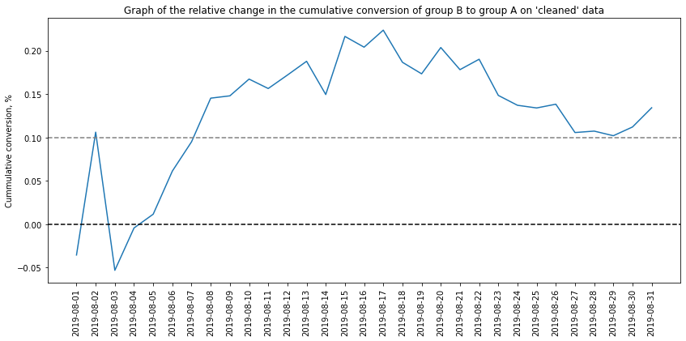

```python
plt.figure(figsize=(14, 6))
plt.plot(dataClean['date'],
         dataClean['conversionCummulativeB']/dataClean['conversionCummulativeA']-1)

plt.title("Graph of the relative change in the cumulative conversion of group B to group A on 'cleaned' data")
plt.ylabel("Cummulative conversion, %")
plt.axhline(y=0, color='black', linestyle='--')
plt.axhline(y=0.1, color='grey', linestyle='--')
plt.xticks(rotation=90);
```

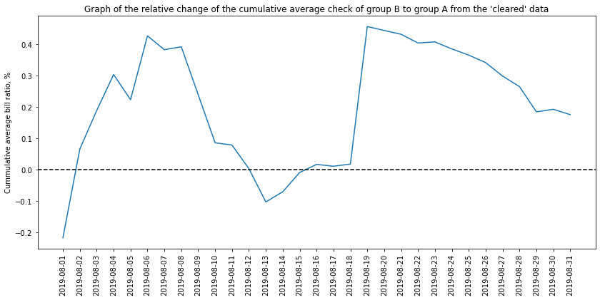

```python
plt.figure(figsize=(14, 6))
plt.plot(dataClean['date'],
         (dataClean['revenueCummulativeB']/dataClean['ordersCummulativeB'])
         /(dataClean['revenueCummulativeA']/dataClean['ordersCummulativeA'])-1)

plt.axhline(y=0, color='black', linestyle='--')
plt.ylabel("Cummulative average bill ratio, %")
plt.title("Graph of the relative change of the cumulative average check of group B to group A from the 'cleared' data")
plt.xticks(rotation=90);
```

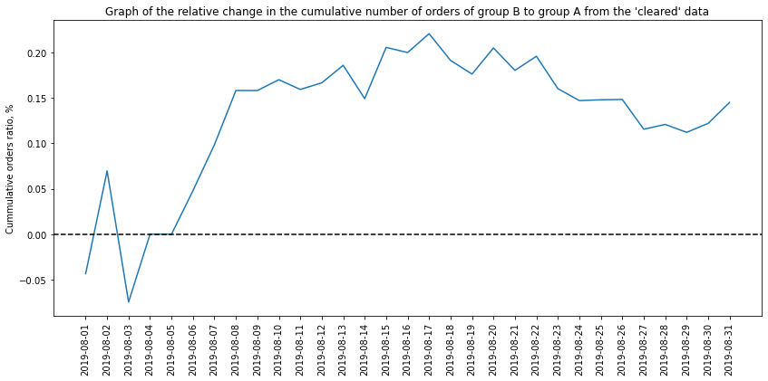

```python
plt.figure(figsize=(14, 6))
plt.plot(dataClean['date'],
         dataClean['ordersCummulativeB']/dataClean['ordersCummulativeA']-1)

plt.axhline(y=0, color='black', linestyle='--')
plt.ylabel("Cummulative orders ratio, %")
plt.title("Graph of the relative change in the cumulative number of orders of group B to group A from the 'cleared' data")
plt.xticks(rotation=90);
```